# AUC integration methods

# Integration methods for Area Under the Concentration-Time curve (AUC)

There are 3 methods for choosing how to integrate the AUC between two concentration measurements in `PKNCA`. They are lin up/log down, linear and lin-log. Additionally, there are 3 methods for extrapolating after the last concentration above the limit of quantification. They are AUCinf, AUClast and AUCall. Other methods of calculating AUC (such as AUC<sub>tau</sub> and AUC<sub>int</sub>) are made with variants of these.

# Definitions and abbreviations

- AUC: Area under the concentration-time curve
- BLQ: Below the lower limit of quantification
- LLOQ: lower limit of quantification
- NCA: Noncompartmental analysis
- Profile: A set of concentration-time points for calculation
- T<sub>last</sub>: The last concentration above the limit of quantification within a profile
- T<sub>max</sub>: The time of the maximum concentration

# Description of methods of integrating between two concentrations before T<sub>last</sub>

Note that other NCA tools may not describe interpolation as zero. The zero-interpolation rules are used by PKNCA to assist with other methods used across the suite of tools for interpolation and data cleaning within PKNCA. The zero-interpolation rules could be swapped for linear trapezoidal rules with the same effects here.

## Linear up/logarithmic down (`"lin up/log down"`) interpolation

Linear up/logarithmic down interpolation is the most commonly used method for PK, and it is the default for `PKNCA`.

Linear up/logarithmic down interpolation is often used when an exogenous substance is dosed and measured, and when the elimination likely occurs by first-order elimination from the body.

## Linear trapezoidal (`"linear"`) interpolation

Linear trapezoidal interpolation is often used when an endogenous substance is measured (and possibly dosed), and when the elimination may not occur by first-order elimination processes.

Linear trapezoidal interpolation uses the following rules in order for each pair of concentrations through T<sub>last</sub>:

1. If concentrations are both zero, interpolate as zero; and
2. Use linear interpolation for all other times (this could be the only rule).

## Linear to T<sub>max</sub>/logarithmic after T<sub>max</sub> (`"lin-log"`) interpolation

Linear to T<sub>max</sub>/logarithmic after T<sub>max</sub> interpolation is infrequently used. It uses the following rules in order for each pair of concentrations through T<sub>last</sub>:

1. If concentrations are both zero, interpolate as zero;
2. If concentrations are before T<sub>max</sub>, use linear interpolation;
3. If concentrations are after T<sub>max</sub> (and before T<sub>last</sub>) and either concentration is zero, use linear interpolation; and
4. If concentrations are after T<sub>max</sub> and neither is zero, use logarithmic interpolation.

# Description of methods of integrating between two concentrations after T<sub>last</sub>

## `"AUClast"` extrapolation

AUClast extrapolation after T<sub>last</sub> is the simplest. It is no extrapolation; the extrapolated AUC integral is zero.

## `"AUCall"` extrapolation

AUCall extrapolation after T<sub>last</sub> has two rules:

1. If the last concentration measured is above the limit of quantification (in other words, the last time is T<sub>last</sub>), then no extrapolation is done; otherwise
2. Integrate linearly the triangle between T<sub>last</sub> and the time of zero concentration after T<sub>last</sub>.

## `"AUCinf"` extrapolation

AUCinf extrapolation requires estimation of a half-life. It extrapolates using the equation

$Extrap = \frac{C_{last}}{\lambda_z}$

# Examples

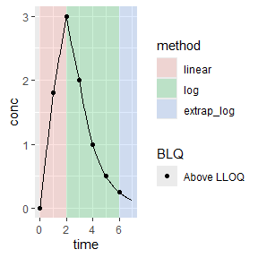

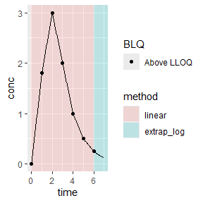

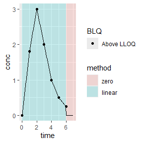

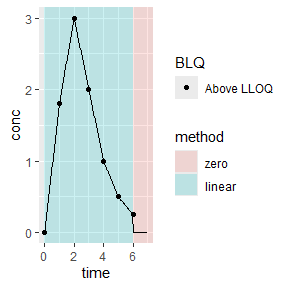

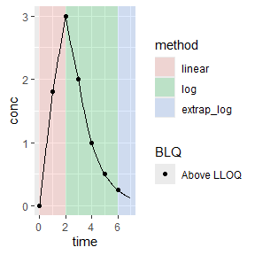

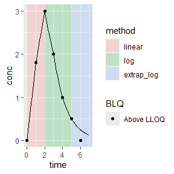

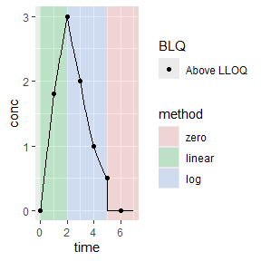

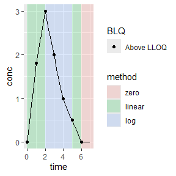

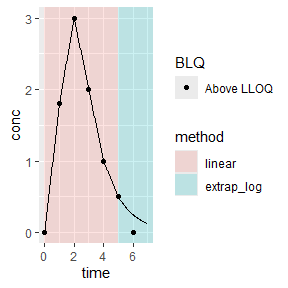

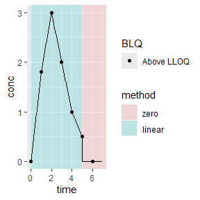

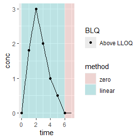

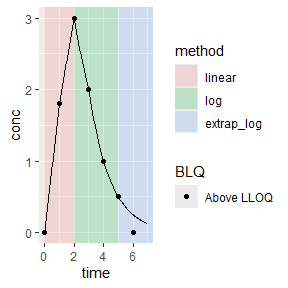

[11 more figures not shown]